# Grand Fir / Snowbrush Microbiome

**Figure 16**

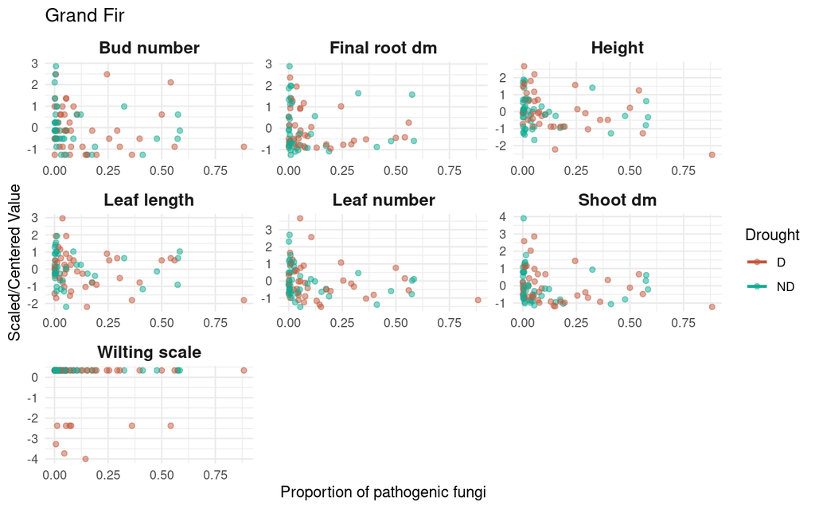

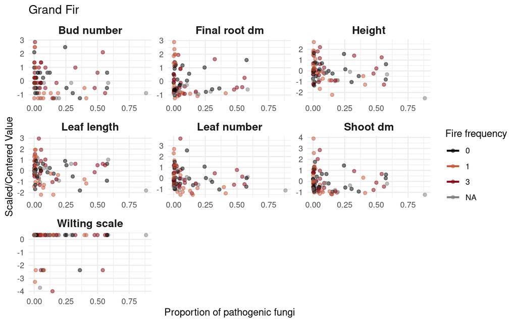

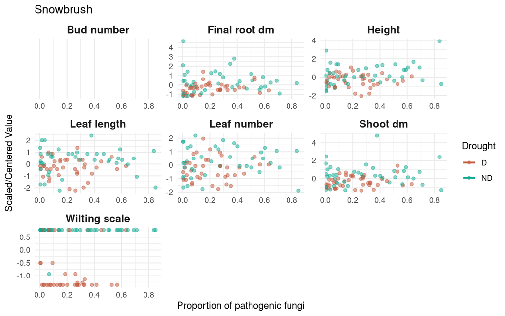

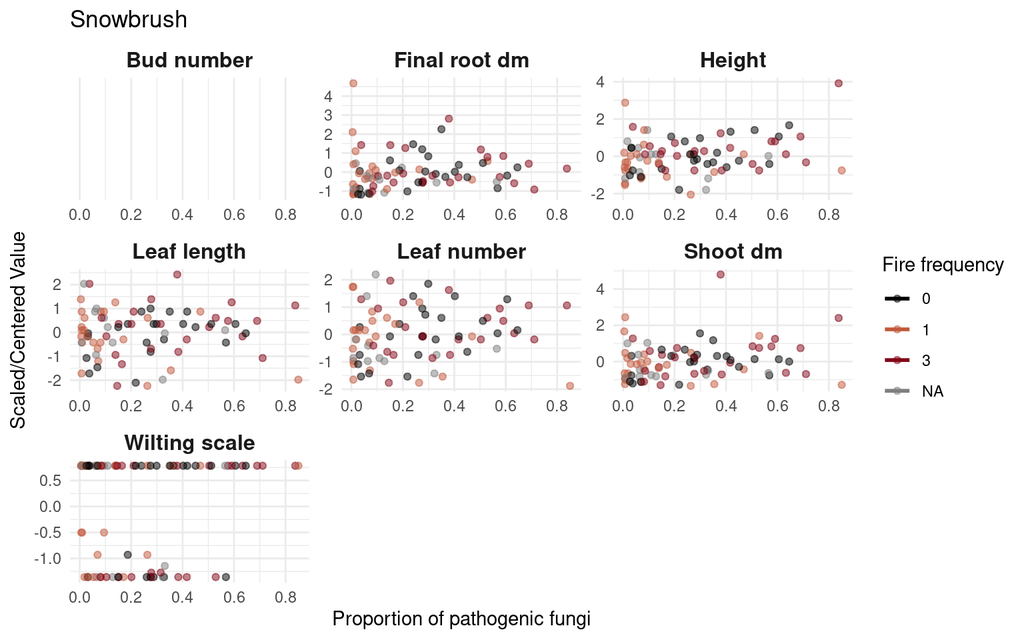

**Table 6**

| effect | term | estimate | std.error | statistic | df | p.value | species |
| --- | --- | --- | --- | --- | --- | --- | --- |
| fixed | (Intercept) | -0.3847 | 0.1554 | -2.4763 | 10.3037 | 0.0321 | Ceanothus |
| fixed | proportion_pathogen | -0.0765 | 0.3571 | -0.2142 | 481.0194 | 0.8305 | Ceanothus |
| fixed | droughtND | 0.6741 | 0.1251 | 5.3868 | 478.1963 | 0.0000 | Ceanothus |
| fixed | proportion_pathogen:droughtND | 0.4320 | 0.4147 | 1.0417 | 479.3039 | 0.2981 | Ceanothus |
| fixed | (Intercept) | -0.0686 | 0.2101 | -0.3265 | 7.1573 | 0.7534 | Abies |
| fixed | proportion_pathogen | -0.1818 | 0.2842 | -0.6398 | 573.1129 | 0.5226 | Abies |
| fixed | droughtND | 0.1919 | 0.0886 | 2.1646 | 573.6108 | 0.0308 | Abies |
| fixed | proportion_pathogen:droughtND | -0.6103 | 0.4252 | -1.4352 | 573.5293 | 0.1518 | Abies |
| fixed | (Intercept) | -0.2647 | 0.1512 | -1.7507 | 10.5999 | 0.1088 | Ceanothus |
| fixed | proportion_mutualist | -0.3757 | 0.2059 | -1.8246 | 478.0381 | 0.0687 | Ceanothus |
| fixed | droughtND | 0.5233 | 0.1298 | 4.0310 | 477.7130 | 0.0001 | Ceanothus |
| fixed | proportion_mutualist:droughtND | 0.7054 | 0.2734 | 2.5804 | 478.2614 | 0.0102 | Ceanothus |
| fixed | (Intercept) | -0.1068 | 0.2240 | -0.4767 | 9.3338 | 0.6446 | Abies |
| fixed | proportion_mutualist | 0.0251 | 0.1663 | 0.1506 | 572.6223 | 0.8803 | Abies |
| fixed | droughtND | 0.1075 | 0.1439 | 0.7472 | 573.1318 | 0.4553 | Abies |
| fixed | proportion_mutualist:droughtND | 0.0540 | 0.2282 | 0.2368 | 574.9668 | 0.8129 | Abies |

# **Beta-Diversity**

## **Bacteria**

**Figure 17**

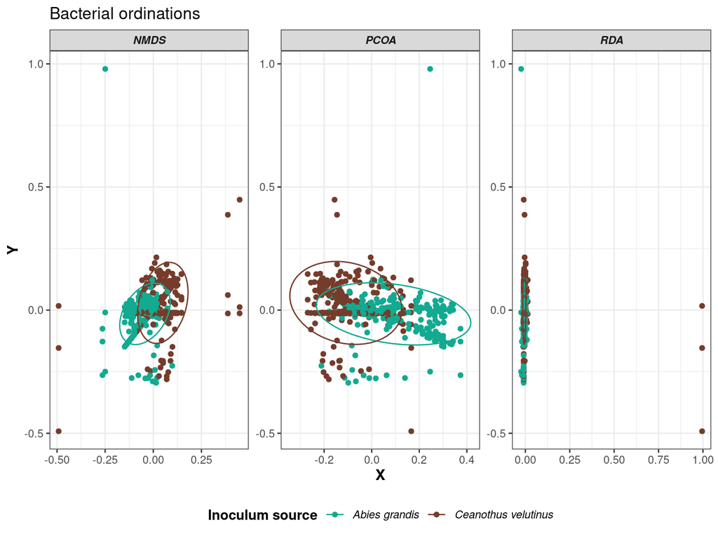

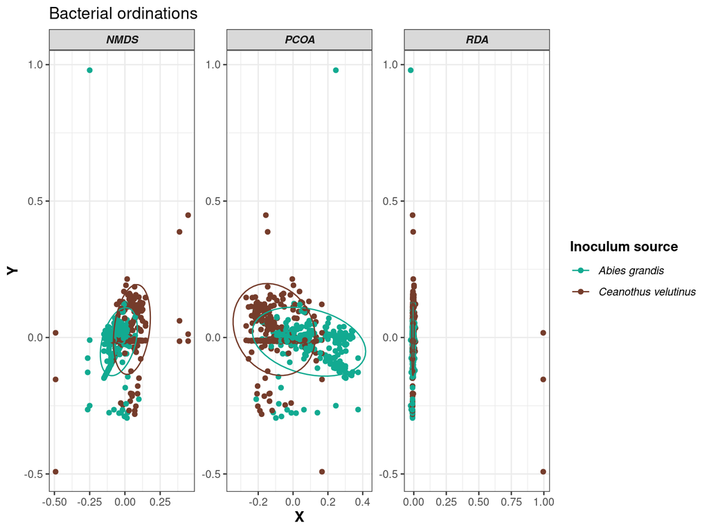

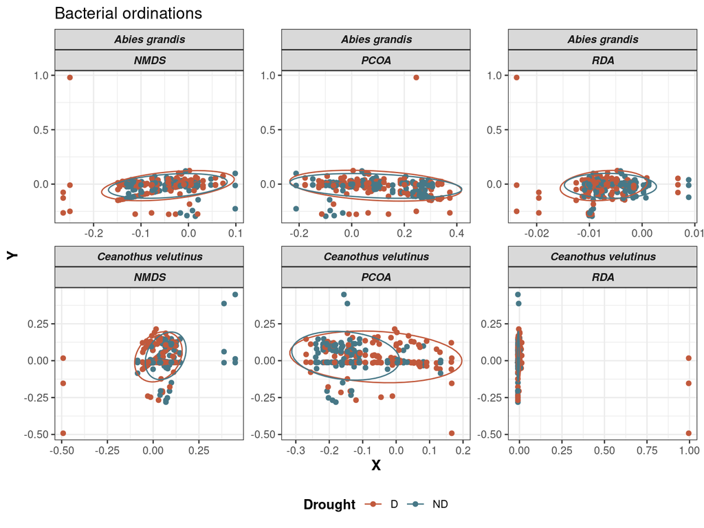

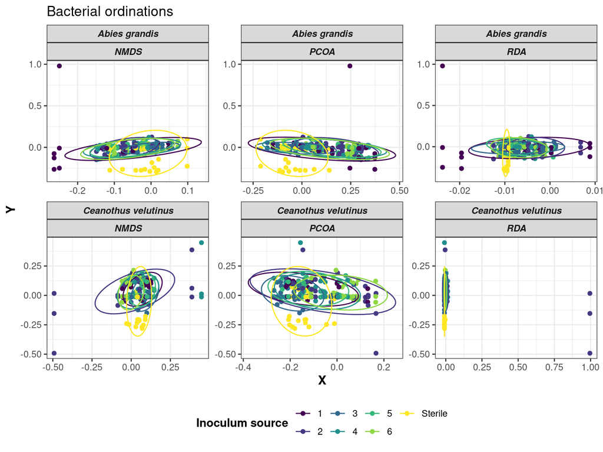

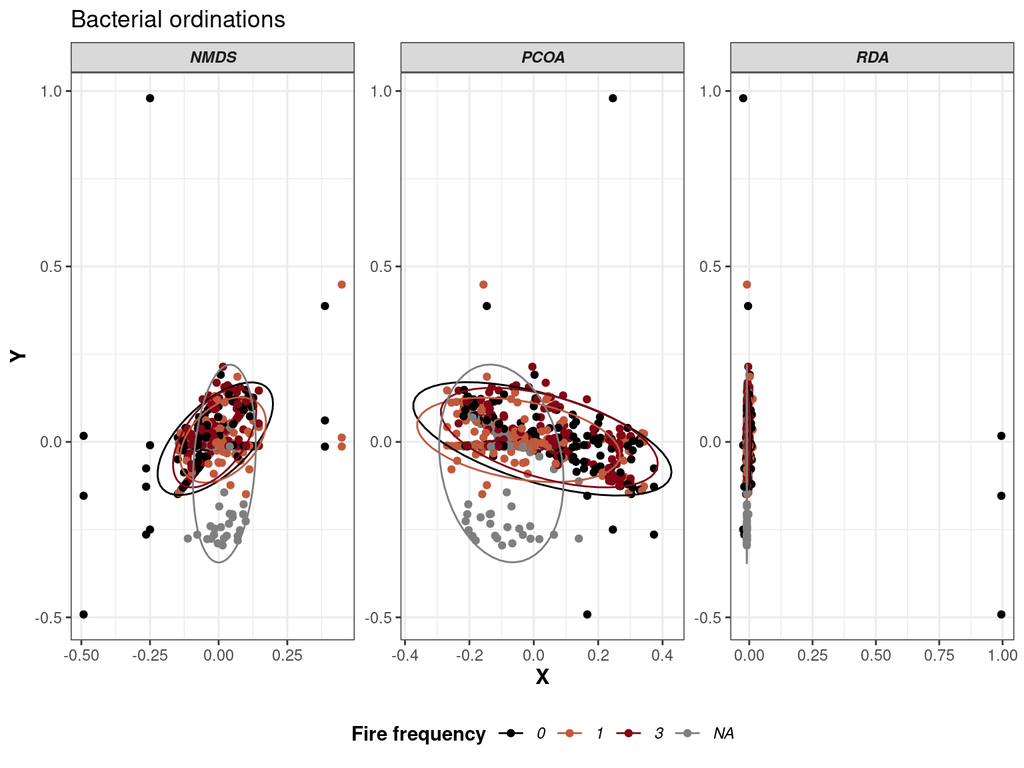

**Table 7**

```
## PermANOVA run without outlier Sterile-inoculum root samples...
```

| term | df | SumOfSqs | R2 | statistic | p.value |
| --- | --- | --- | --- | --- | --- |
| host | 1 | 3.8414120 | 0.0687480 | 12.836684 | 0.001 |
| inoculum_site | 5 | 7.1862718 | 0.1286094 | 4.802812 | 0.001 |
| drought | 1 | 0.8088162 | 0.0144750 | 2.702787 | 0.001 |
| host:inoculum_site | 5 | 3.6135887 | 0.0646707 | 2.415075 | 0.001 |
| host:drought | 1 | 0.7562988 | 0.0135351 | 2.527292 | 0.001 |
| inoculum_site:drought | 5 | 1.9283329 | 0.0345105 | 1.288766 | 0.005 |
| host:inoculum_site:drought | 5 | 1.8316856 | 0.0327808 | 1.224173 | 0.018 |
| Residual | 120 | 35.9103196 | 0.6426704 | NA | NA |
| Total | 143 | 55.8767255 | 1.0000000 | NA | NA |

## **Fungi**

**Figure 18**

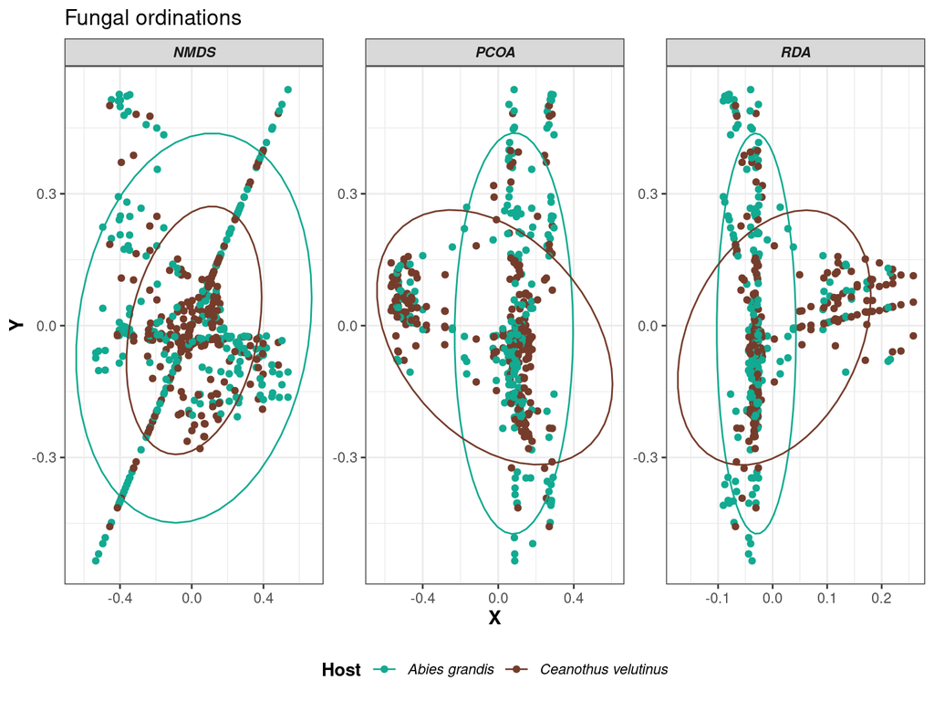

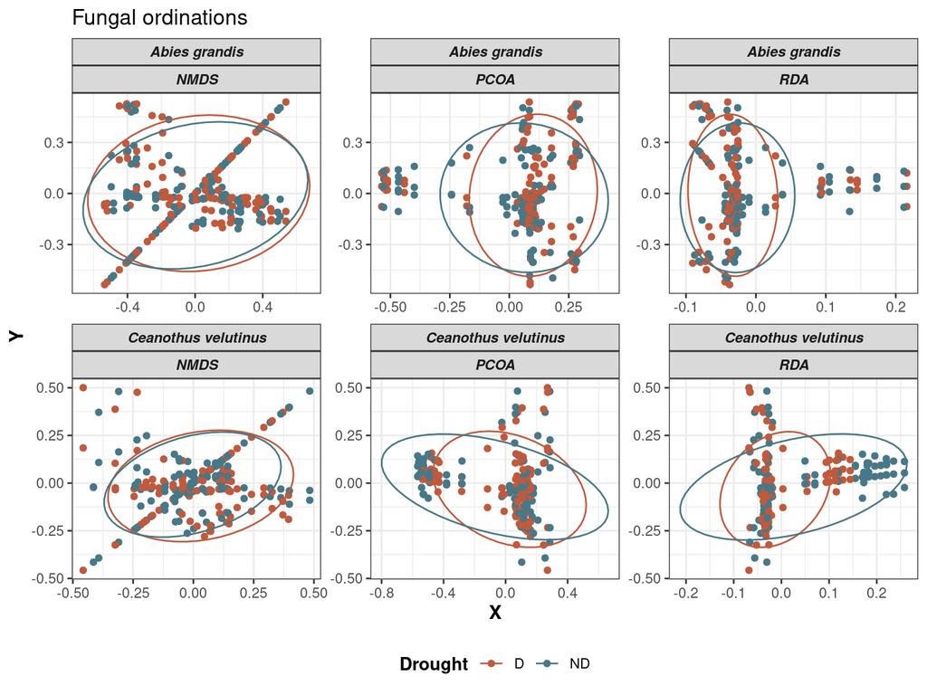

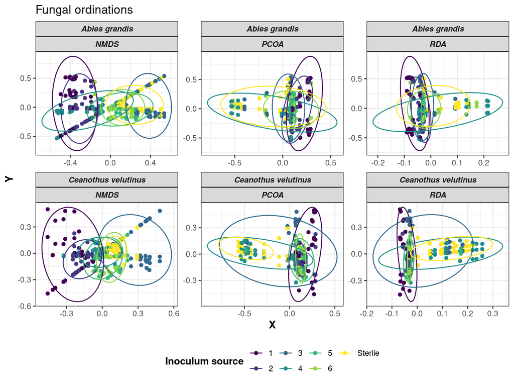

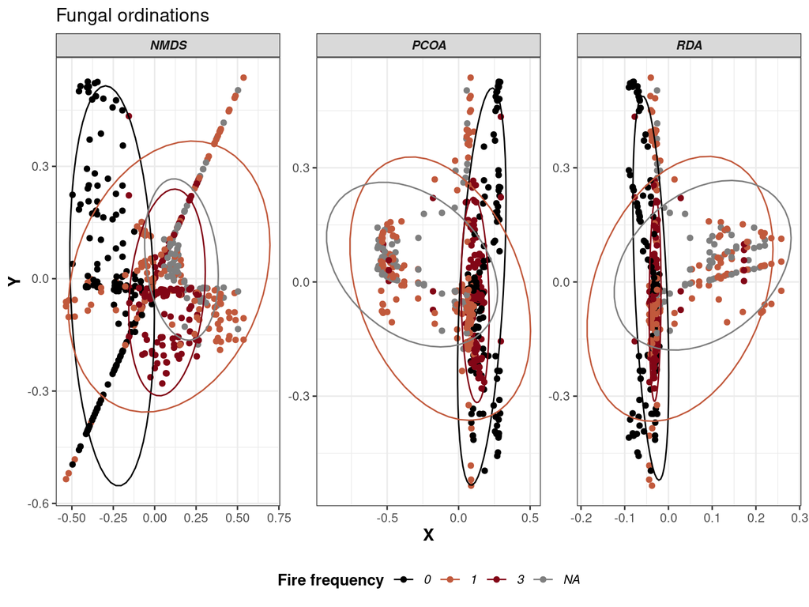

**Table 7**

```
## PermANOVA run without outlier Sterile-inoculum root samples...
```

| term | df | SumOfSqs | R2 | statistic | p.value |
| --- | --- | --- | --- | --- | --- |
| host | 1 | 1.8555637 | 0.0288094 | 5.687460 | 0.001 |
| inoculum_site | 5 | 14.1030579 | 0.2189636 | 8.645414 | 0.001 |
| drought | 1 | 0.6383236 | 0.0099106 | 1.956516 | 0.007 |
| host:inoculum_site | 5 | 4.4734164 | 0.0694541 | 2.742280 | 0.001 |
| host:drought | 1 | 0.4690934 | 0.0072831 | 1.437811 | 0.082 |
| inoculum_site:drought | 5 | 2.0071801 | 0.0311634 | 1.230436 | 0.052 |
| host:inoculum_site:drought | 5 | 1.7109789 | 0.0265646 | 1.048859 | 0.351 |
| Residual | 120 | 39.1506299 | 0.6078512 | NA | NA |
| Total | 143 | 64.4082440 | 1.0000000 | NA | NA |

## **AMF**

**Figure 19**

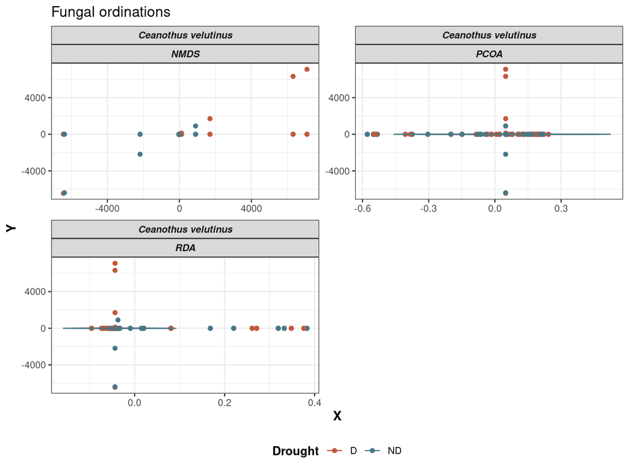

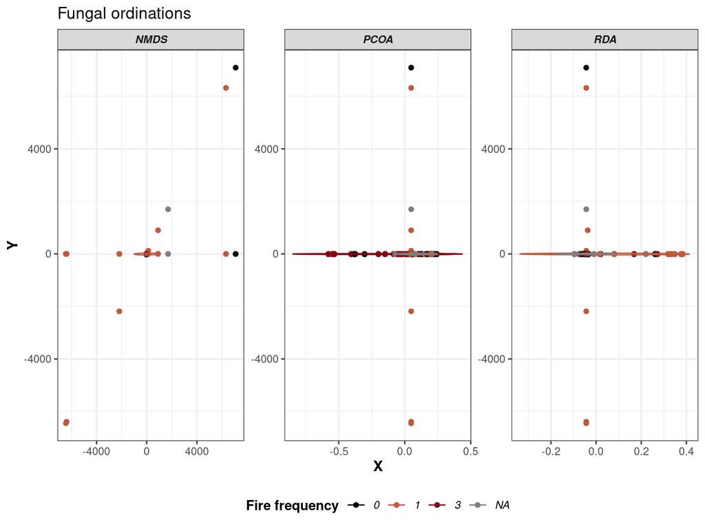

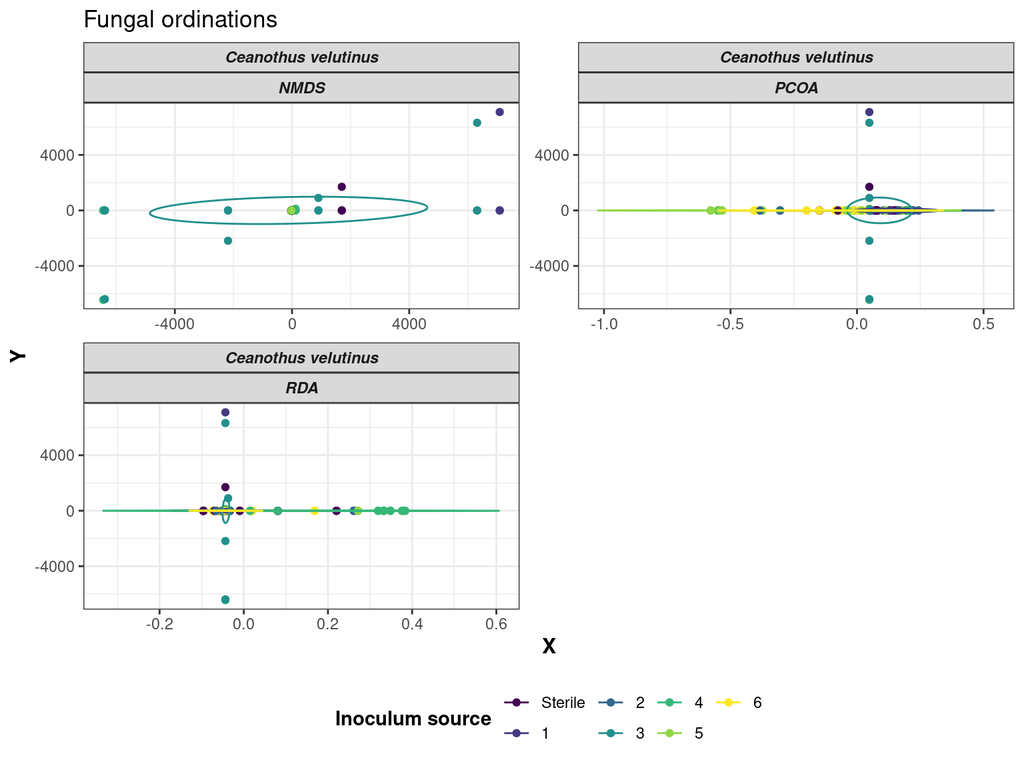

**Table 8**

```
## PermANOVA run without outlier Sterile-inoculum root samples...
```

| term | df | SumOfSqs | R2 | statistic | p.value |
| --- | --- | --- | --- | --- | --- |
| inoculum_site | 6 | 6.9907731 | 0.2129210 | 2.9819777 | 0.001 |
| drought | 1 | 0.3007071 | 0.0091588 | 0.7696159 | 0.777 |
| inoculum_site:drought | 6 | 2.0978089 | 0.0638939 | 0.8948394 | 0.770 |
| Residual | 60 | 23.4434120 | 0.7140263 | NA | NA |
| Total | 73 | 32.8327011 | 1.0000000 | NA | NA |

# **Important Taxa**

## **Bacteria**

### **Differential Abundance**

**Figure 20**

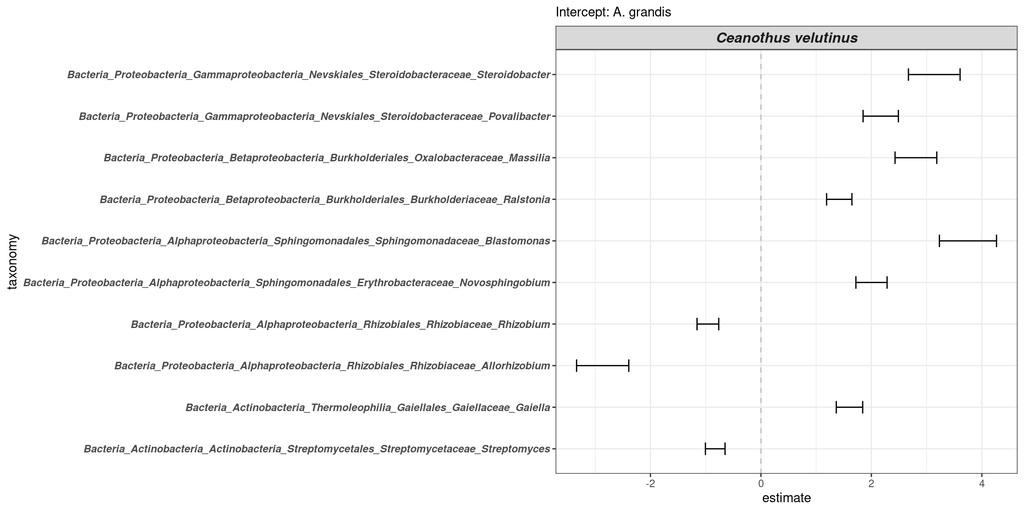

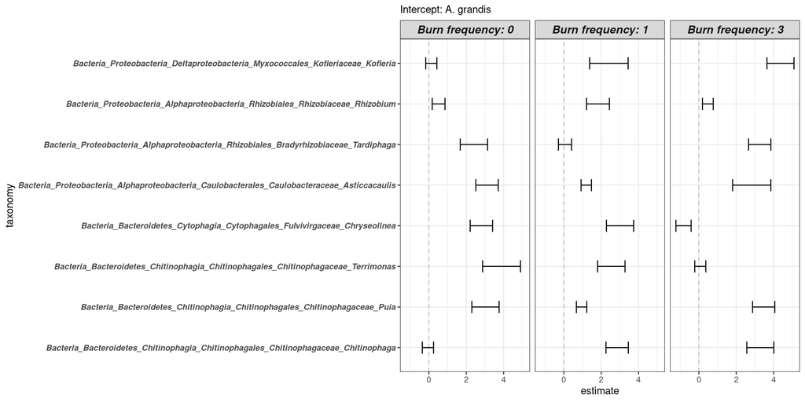

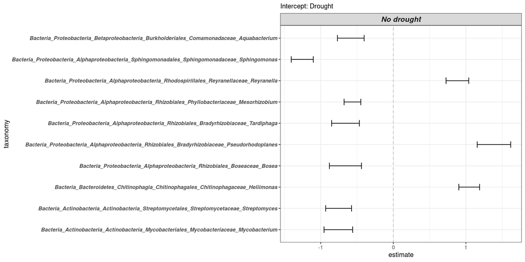

### **Relative Abundances of ‘important’ taxa in root samples**

**Figure 21**

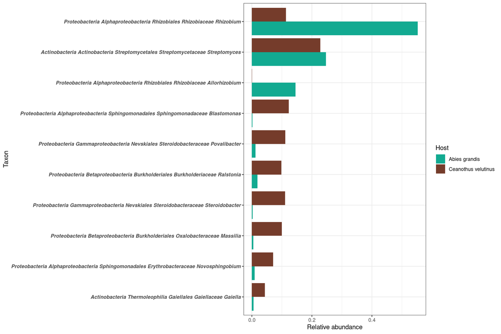

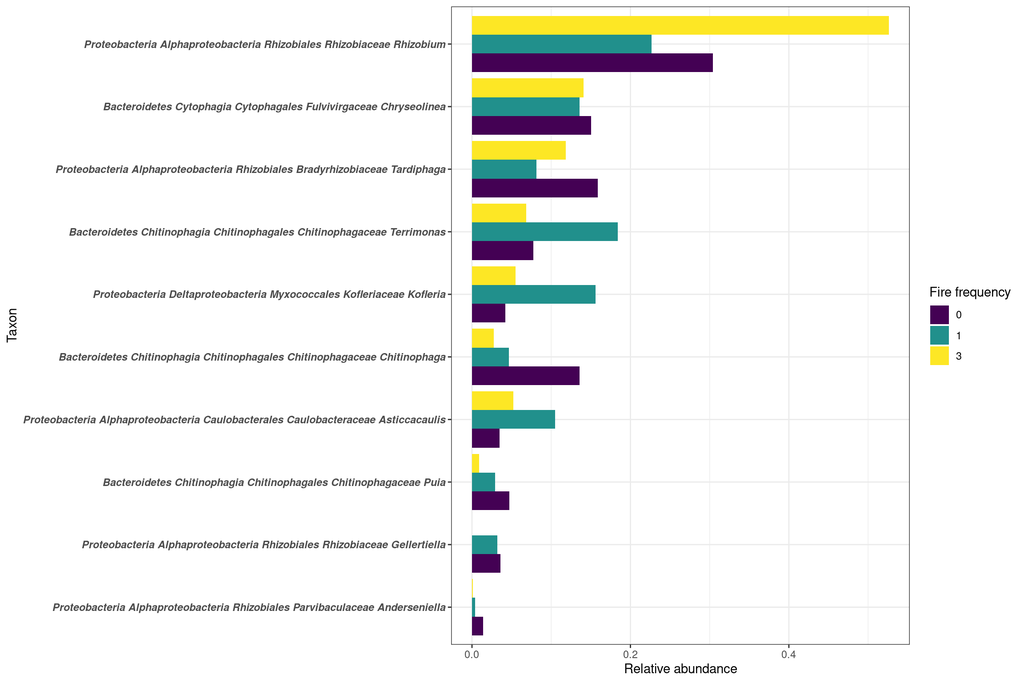

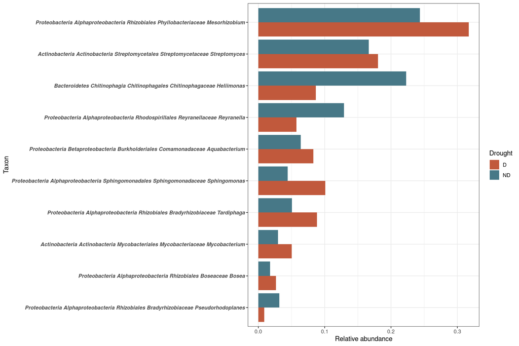

## **Fungi**

### **Differential Abundance**

**Figure 22**

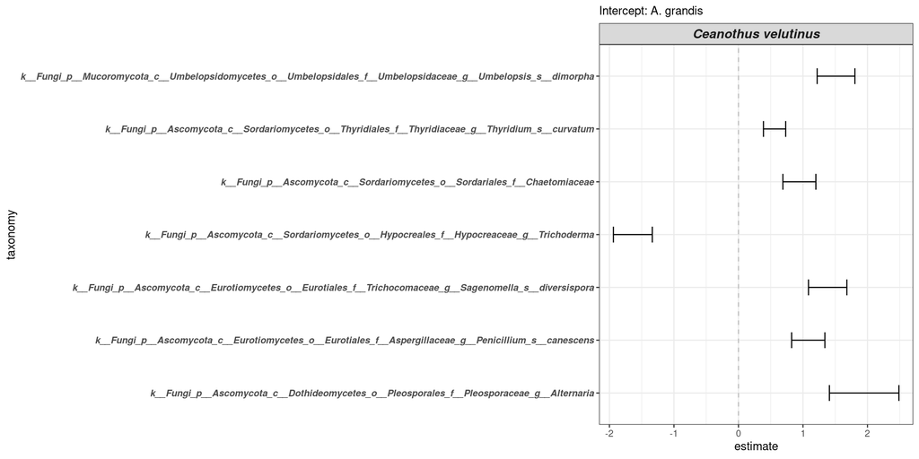

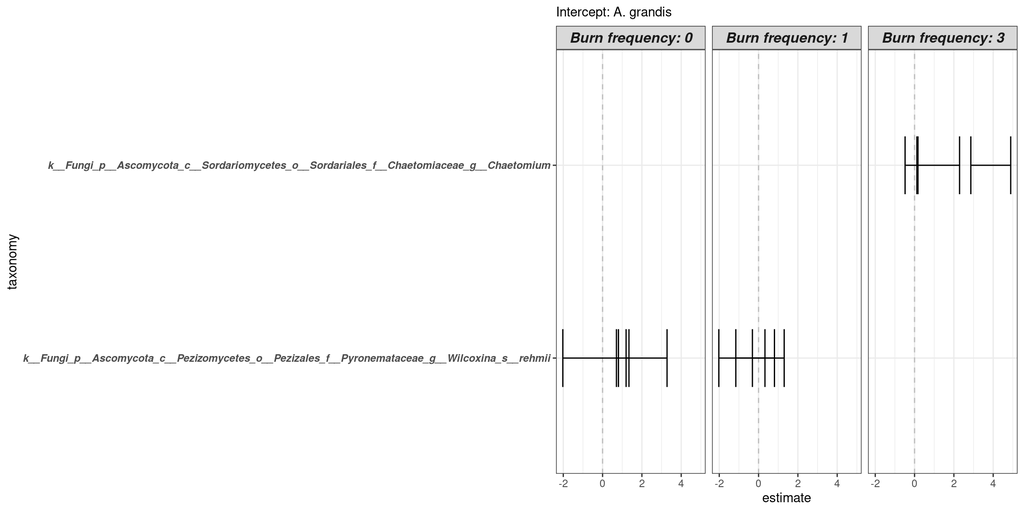

**No fungal taxa were found to have significant differential abundance between drought levels**

### **Relative Abundances of ‘important’ taxa in root samples**

**Figure 23**

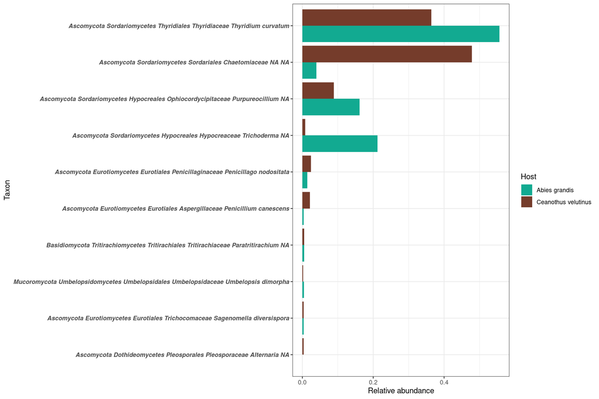

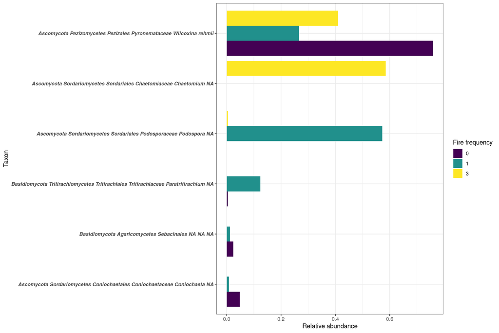

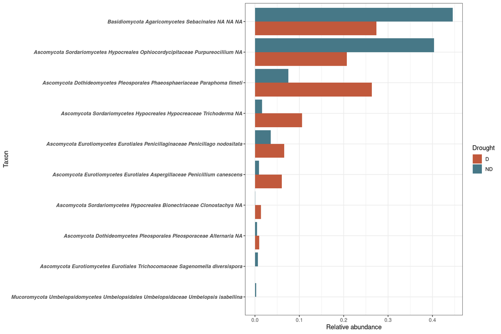

## **AMF**

### **Differential Abundance**

**Figure 24**

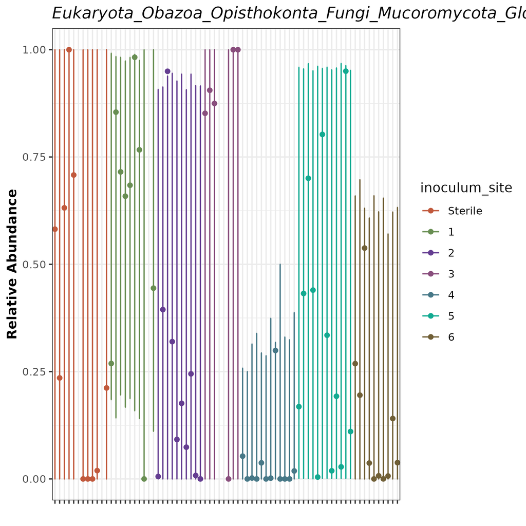

**No fungal taxa were found to have significant differential abundance between drought levels**

### **Relative Abundances of ‘important’ taxa in root samples**

**Figure 25**

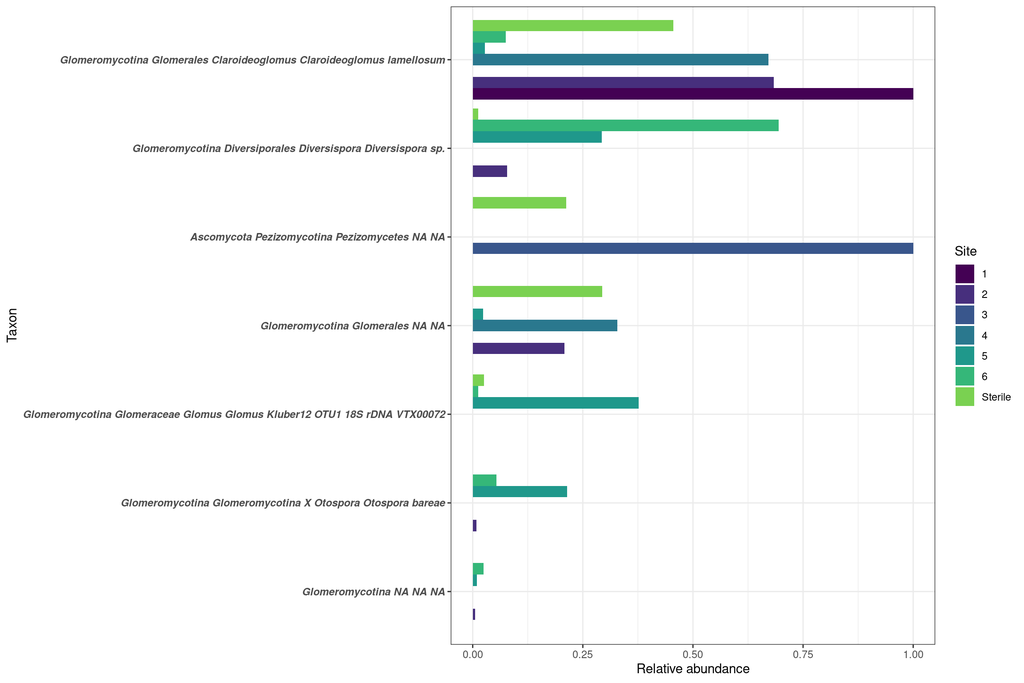

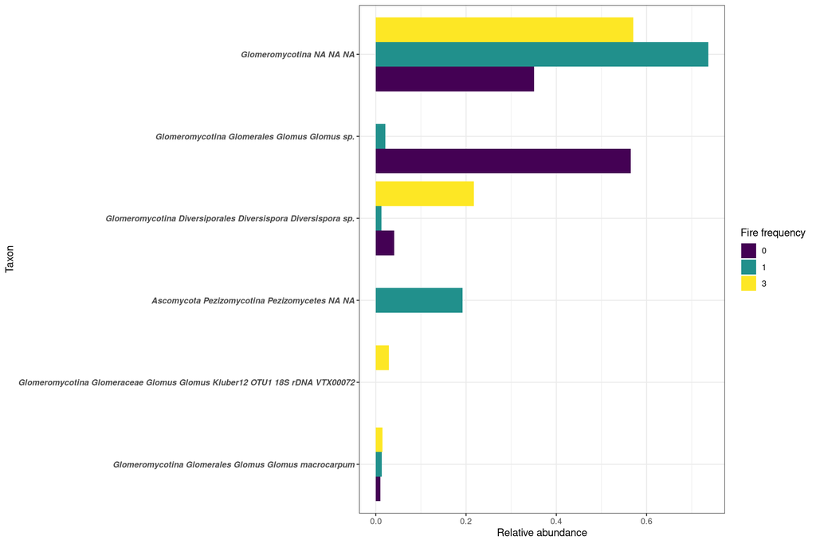

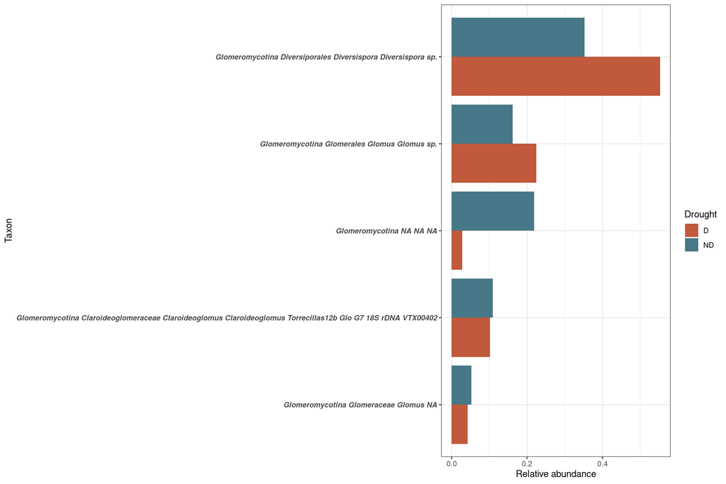

# **Phylogenetic properties**

## **Bacteria**

- Still kind of messy
- What specific questions do we need to address with this?

## **Fungi**

- Phylogenetic dispersion is tricky with ITS markers :(
- Could try GhostTree for fungi of interest that come up as ‘unknown’

# **Network properties**

## **Selected network attributes**

**Figure 26**

[figure not shown]

## **Network properties vs Plant Health**

(Composite scaled-centered plant health measures)

**Table 9**

```
## Plant_Growth_Response ~ species * kingdom * (n_vertices + n_edges +
##     mean_dist + mean_betweenness + mean_closeness + global_effic +
##     clustering_coeficient + max_degree)
```

**Table 10**

| term | estimate | std.error | statistic | p.value |
| --- | --- | --- | --- | --- |
| (Intercept) | -0.5543907 | 2.1316421 | -0.2600768 | 0.7948531 |
| speciesSnowbrush | 0.6542343 | 2.0842474 | 0.3138947 | 0.7536604 |
| kingdomBacteria | 0.7978266 | 2.1468131 | 0.3716330 | 0.7102375 |
| kingdomFungi | -0.8562899 | 1.6360027 | -0.5234037 | 0.6007986 |
| n_vertices | 0.0291094 | 0.0107670 | 2.7035694 | 0.0069655 |
| n_edges | -0.0024261 | 0.0012869 | -1.8852135 | 0.0596639 |
| mean_dist | 0.1615886 | 0.4334980 | 0.3727550 | 0.7094025 |
| mean_betweenness | -0.0179824 | 0.0069480 | -2.5881320 | 0.0097768 |
| mean_closeness | 3.5648124 | 6.0927745 | 0.5850885 | 0.5586080 |
| global_effic | 0.2433596 | 2.2006359 | 0.1105861 | 0.9119647 |
| clustering_coeficient | -0.0752389 | 0.5987383 | -0.1256624 | 0.9000221 |
| max_degree | -0.0063211 | 0.0050534 | -1.2508744 | 0.2112458 |
| speciesSnowbrush:kingdomBacteria | -2.5890158 | 2.2315970 | -1.1601628 | 0.2462338 |
| speciesSnowbrush:kingdomFungi | NA | NA | NA | NA |
| speciesSnowbrush:n_vertices | -0.0143278 | 0.0070904 | -2.0207346 | 0.0435487 |
| speciesSnowbrush:n_edges | 0.0009879 | 0.0005423 | 1.8215202 | 0.0687988 |
| speciesSnowbrush:mean_dist | -0.1533864 | 0.4203805 | -0.3648752 | 0.7152746 |
| speciesSnowbrush:mean_betweenness | 0.0087602 | 0.0042885 | 2.0427016 | 0.0413195 |
| speciesSnowbrush:mean_closeness | -3.8685083 | 6.0811564 | -0.6361468 | 0.5248128 |
| speciesSnowbrush:global_effic | -0.3158048 | 2.1737739 | -0.1452795 | 0.8845168 |
| speciesSnowbrush:clustering_coeficient | 0.1621361 | 0.5926434 | 0.2735812 | 0.7844578 |
| speciesSnowbrush:max_degree | 0.0049979 | 0.0031582 | 1.5825020 | 0.1138219 |
| kingdomBacteria:n_vertices | -0.0329669 | 0.0121835 | -2.7058628 | 0.0069179 |
| kingdomFungi:n_vertices | -0.0165321 | 0.0091401 | -1.8087389 | 0.0707640 |
| kingdomBacteria:n_edges | 0.0024004 | 0.0030422 | 0.7890472 | 0.4302542 |
| kingdomFungi:n_edges | 0.0016689 | 0.0011998 | 1.3909118 | 0.1645329 |
| kingdomBacteria:mean_dist | -0.1937280 | 0.4375996 | -0.4427060 | 0.6580653 |
| kingdomFungi:mean_dist | 0.1932210 | 0.3090319 | 0.6252461 | 0.5319390 |
| kingdomBacteria:mean_betweenness | 0.0200096 | 0.0073609 | 2.7183639 | 0.0066635 |
| kingdomFungi:mean_betweenness | 0.0098666 | 0.0061194 | 1.6123424 | 0.1071738 |
| kingdomBacteria:mean_closeness | -3.7281546 | 6.0969418 | -0.6114795 | 0.5410083 |
| kingdomFungi:mean_closeness | -1.1787054 | 5.0414341 | -0.2338036 | 0.8151809 |
| kingdomBacteria:global_effic | -0.5827634 | 2.2369624 | -0.2605155 | 0.7945148 |
| kingdomFungi:global_effic | 1.1682005 | 1.7966026 | 0.6502276 | 0.5156808 |
| kingdomBacteria:clustering_coeficient | 0.4787035 | 0.6264813 | 0.7641146 | 0.4449625 |
| kingdomFungi:clustering_coeficient | -0.6050180 | 0.4565936 | -1.3250690 | 0.1854230 |
| kingdomBacteria:max_degree | 0.0182595 | 0.0103733 | 1.7602447 | 0.0786437 |
| kingdomFungi:max_degree | 0.0034425 | 0.0043117 | 0.7984040 | 0.4248081 |
| speciesSnowbrush:kingdomBacteria:n_vertices | 0.0326440 | 0.0120103 | 2.7180067 | 0.0066707 |
| speciesSnowbrush:kingdomFungi:n_vertices | NA | NA | NA | NA |
| speciesSnowbrush:kingdomBacteria:n_edges | -0.0025587 | 0.0034005 | -0.7524393 | 0.4519476 |
| speciesSnowbrush:kingdomFungi:n_edges | NA | NA | NA | NA |
| speciesSnowbrush:kingdomBacteria:mean_dist | 0.4770298 | 0.4435839 | 1.0753992 | 0.2824314 |
| speciesSnowbrush:kingdomFungi:mean_dist | NA | NA | NA | NA |
| speciesSnowbrush:kingdomBacteria:mean_betweenness | -0.0214609 | 0.0063300 | -3.3903559 | 0.0007228 |
| speciesSnowbrush:kingdomFungi:mean_betweenness | NA | NA | NA | NA |
| speciesSnowbrush:kingdomBacteria:mean_closeness | 6.3019795 | 6.1167331 | 1.0302852 | 0.3031022 |
| speciesSnowbrush:kingdomFungi:mean_closeness | NA | NA | NA | NA |
| speciesSnowbrush:kingdomBacteria:global_effic | 3.5991501 | 2.4129321 | 1.4916085 | 0.1360880 |
| speciesSnowbrush:kingdomFungi:global_effic | NA | NA | NA | NA |
| speciesSnowbrush:kingdomBacteria:clustering_coeficient | -1.3580924 | 0.7086829 | -1.9163612 | 0.0555776 |
| speciesSnowbrush:kingdomFungi:clustering_coeficient | NA | NA | NA | NA |
| speciesSnowbrush:kingdomBacteria:max_degree | -0.0102114 | 0.0123216 | -0.8287420 | 0.4074299 |
| speciesSnowbrush:kingdomFungi:max_degree | NA | NA | NA | NA |

_____

# **Soil chemistry**

**Overview of soil properties for each inoculum source:**

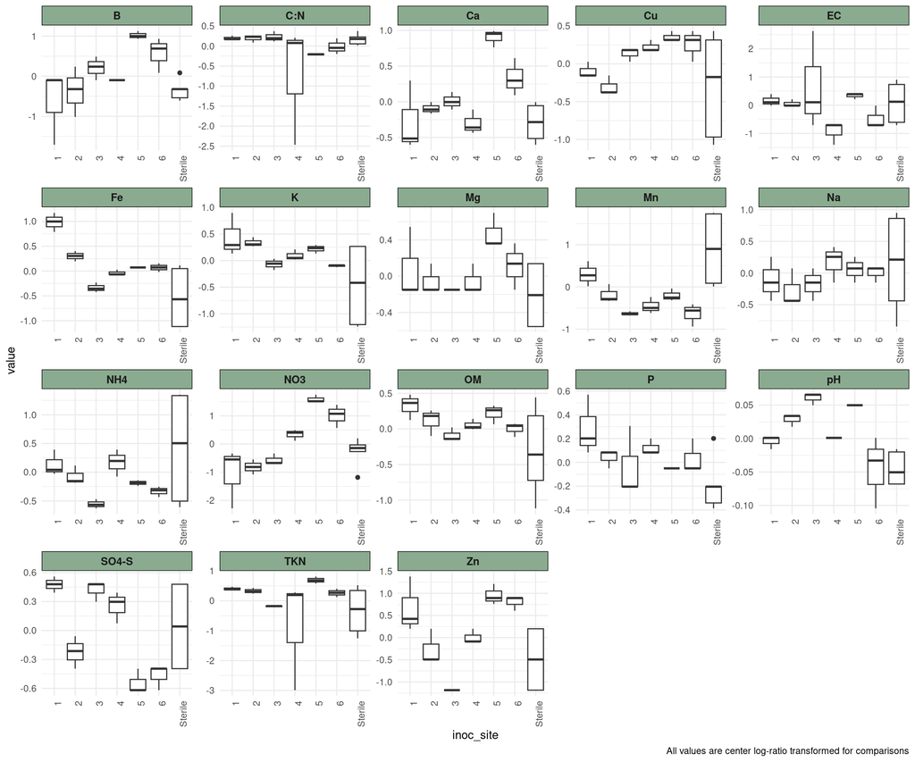

Testing for significant differences between the samples…

Here are the soil properties that differ significantly between inoculum sources. Sterile inoculum soils are set as the intercept. The stats below pretty nicely reflect the obvious patterns in the overall figure.

| term | estimate | std.error | statistic | p.value |
| --- | --- | --- | --- | --- |
| Mn | 1.248 | 0.268 | 4.658 | 0.000 |
| NH4 | 0.770 | 0.268 | 2.875 | 0.004 |
| Fe:inoc_site1 | 1.516 | 0.328 | 4.618 | 0.000 |
| K:inoc_site1 | 0.904 | 0.328 | 2.753 | 0.006 |
| NO3:inoc_site1 | -0.793 | 0.328 | -2.417 | 0.016 |
| TKN:inoc_site1 | 0.735 | 0.328 | 2.240 | 0.026 |
| Zn:inoc_site1 | 1.160 | 0.328 | 3.536 | 0.000 |
| Fe:inoc_site2 | 0.831 | 0.328 | 2.532 | 0.012 |
| K:inoc_site2 | 0.801 | 0.328 | 2.440 | 0.015 |
| Mn:inoc_site2 | -1.081 | 0.328 | -3.294 | 0.001 |
| TKN:inoc_site2 | 0.660 | 0.328 | 2.010 | 0.045 |
| Mn:inoc_site3 | -1.526 | 0.328 | -4.648 | 0.000 |
| NH4:inoc_site3 | -0.976 | 0.328 | -2.973 | 0.003 |
| Zn:inoc_site3 | -0.693 | 0.328 | -2.112 | 0.035 |
| C:N:inoc_site4 | -0.893 | 0.328 | -2.721 | 0.007 |
| EC:inoc_site4 | -1.026 | 0.328 | -3.127 | 0.002 |
| Mn:inoc_site4 | -1.349 | 0.328 | -4.110 | 0.000 |
| B:inoc_site5 | 1.369 | 0.328 | 4.171 | 0.000 |
| Ca:inoc_site5 | 1.192 | 0.328 | 3.631 | 0.000 |
| K:inoc_site5 | 0.683 | 0.328 | 2.080 | 0.038 |
| Mg:inoc_site5 | 0.682 | 0.328 | 2.078 | 0.039 |
| Mn:inoc_site5 | -1.099 | 0.328 | -3.350 | 0.001 |
| NO3:inoc_site5 | 1.854 | 0.328 | 5.649 | 0.000 |
| TKN:inoc_site5 | 1.022 | 0.328 | 3.114 | 0.002 |
| Zn:inoc_site5 | 1.448 | 0.328 | 4.412 | 0.000 |
| B:inoc_site6 | 0.918 | 0.328 | 2.798 | 0.005 |
| Mn:inoc_site6 | -1.535 | 0.328 | -4.678 | 0.000 |
| NH4:inoc_site6 | -0.754 | 0.328 | -2.299 | 0.022 |
| NO3:inoc_site6 | 1.273 | 0.328 | 3.880 | 0.000 |
| Zn:inoc_site6 | 1.290 | 0.328 | 3.932 | 0.000 |